# Racist hypothesis notebook

# Analysis Proper

## Import 1GK metadata (for population)

From here: http://ftp.1000genomes.ebi.ac.uk/vol1/ftp/technical/working/20130606_sample_info/20130606_sample_info.xlsx (link embedded in this page: <www.internationalgenome.org/data>)

```r
meta <- read_xlsx(here::here("data", "20130606_sample_info.xlsx"), sheet = "Sample Info") %>% dplyr::select(Sample, Population, Gender)
```

## Read in VCFs with allele counts for target SNPs

```r
# set names
names(vcf_list) <- gsub("snphits_|.vcf.gz", "", list.files(here::here("data"), pattern = glob2rx("snphits_*.gz")))
```

[output not shown]

## Read in SNP data

**NOTE**:

• In the *Lee et al.* (edu_years) data tables, the sheet says: “Notes: Clumping of GWAS results was performed as described in the Supplementary Notes. SNPs are ordered by P-value. Chromosome (CHR) and base pair (BP) positions are reported for human genome build 37 (hg19). *"Allele 1" is the allele whose estimated effect size (Beta) and allele frequency are reported.* Standard errors (SE) and P-values are derived from test statistics that have been adjusted by an estimated LDSC intercept of 1.113. The analysis is based on 10,016,265 SNPs. The average chi-squared statistic is 2.530/2.816 (adjusted and unadjusted, respectively) and lambda GC is 2.038 (unadjusted).”

• In the *Yengo et al.* (height) data tables, the header is self-explanatory.

• In the *Huang et al.* (ibd) data tables, the SNPs have odds ratios rather than betas. Also, the legend says that *A0 is the reference allele and A1 is the tested allele*. p_multi is the -log10(P-value) for multi-variate model.

```r
# create empty list
snps_list <- list()
# add edu_years SNPs
snps_list[["edu_years"]] <- read_xlsx(here::here("data", "20180723_Lee-et-al_supp-tables.xlsx"), sheet = "2. EduYears Lead SNPs", skip = 1, n_max = 1271) %>%
  dplyr::select(snp = "SNP",
                tested_allele = "Allele 1",
                other_allele = "Allele2",
                effect_size = "Effect size",
                p_value = "P-value")
# add height SNPs
snps_list[["height"]] <- read_delim(here::here("data", "20181015_Yengo-et-al_snps_height.txt"), delim = "\t") %>%
  dplyr::select(snp = "SNP",
                tested_allele = "Tested_Allele",
                other_allele = "Other_Allele",
                effect_size = "BETA",
                p_value = "P")
# add ibd SNPs (full list)
snps_list[["ibd_full"]] <- read_xlsx(here::here("data", "20170628_Huang-et-al_supp-table-1.xlsx"), sheet = "list of variants") %>%
  dplyr::mutate(mean_or = (OR_CD + OR_UC) / 2) %>%
  dplyr::select(snp = "variant",
                tested_allele = "A1",
                other_allele = "A0",
                effect_size =  "mean_or",
                p_value = "P_mean_95")
```

```
* trait -> trait...7
* trait -> trait...8
```

```r
# add ibd SNPS - note the "effect size" here is the mean odds ratio across both CD and UC
snps_list[["ibd"]] <- read_xlsx(here::here("data", "20170628_Huang-et-al_supp-table-1.xlsx"), sheet = "list of credible sets") %>%
  dplyr::mutate(mean_or = (OR_CD + OR_UC) / 2) %>%
  dplyr::select(snp = "variant.lead",
                tested_allele = "A1",
                other_allele = "A0",
                effect_size =  "mean_or",
                p_value = "p_multi")
```

### Filter out indels from full IBD list

```r
# filter
snps_list[["ibd_full"]] <- dplyr::slice(snps_list[["ibd_full"]], (ibd_indels * -1))
```

## Create data frames with allele frequencies

```r
# Incorporate into function:
get_alfreq_table <- function(population, snp_df){
  # take only the SNPs that are also in the snp_df
  indexes_to_keep <- which(names(population) %in% snp_df$snp == T)
  population <- population[indexes_to_keep]
  # start loop
  counter <- 0
  population <- lapply(population, function(snp_summary){
    # set counter and extract SNP ID
    counter <<- counter + 1
    snp_id <- names(population)[counter]
    # create final DF
    final_df <- data.frame("allele" = names(snp_summary$allele),
                           "count" = snp_summary$allele,
                           stringsAsFactors = F)
    # get allele frequency
    final_df$al_freq <- final_df$count / sum(final_df$count)
    # pull out effect sizes and p-values from snp_df
    effect_sizes <- data.frame("allele" = c(snp_df$other_allele[snp_df$snp == snp_id],
                                            snp_df$tested_allele[snp_df$snp == snp_id]),
                               "effect_size" = c(0, snp_df$effect_size[snp_df$snp == snp_id]),
                               "p_value" = c(0, snp_df$p_value[snp_df$snp == snp_id]),
                               stringsAsFactors = F)
    # join DFs. Note that it only joins the two alleles in the snp_df
    final_df <- dplyr::left_join(effect_sizes, final_df, by = "allele")
    # remove any rows with NA (caused by having a third allele)
    final_df <- final_df[complete.cases(final_df), ]
    # convert negative effects sizes into positive ones by flipping the allele
    if(any(final_df$effect_size < 0)){
      final_df$effect_size[final_df$effect_size == 0] <- final_df$effect_size[final_df$effect_size < 0] * (-1)
      final_df$effect_size[final_df$effect_size < 0] <- 0
    }
    return(final_df)
  })
  return(population)
}
```

## Create columns for each population

```r
plot_df_lst <- lapply(alcnt_df_filt, function(pheno){
  pheno <- pheno %>% dplyr::select(-count)
  pheno <- tidyr::pivot_wider(data = pheno,
                              names_from = population,
                              names_prefix = "al_freq_",
                              values_from = al_freq)
  return(pheno)
})
```

## Plot

### Set up vectors for phenotype-specific parameters

```r
# Colour palettes
colour_pals <- c("viridis", "inferno", "plasma")
# Line colours
#line_cols <- c("red", "red", "blue")
# Titles
titles <- c("Educational Attainment", "Height", "Inflammatory Bowel Disease")
# Legend title for effect size
legend_title <- c("Effect size (Beta)", "Effect size (Beta)", "Mean odds ratio (CD and UC)")
```

### YRI v CEU

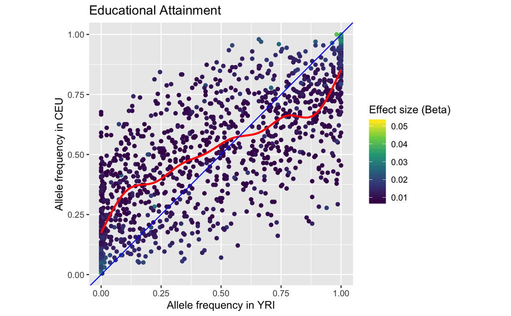

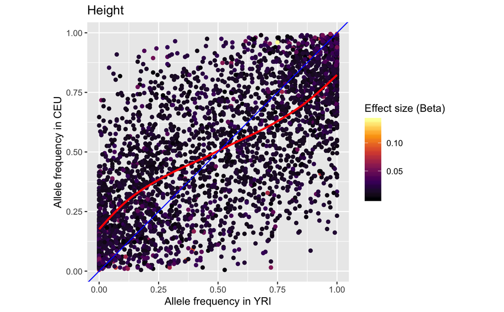

```r
counter <- 0
lapply(plot_df_lst, function(pheno){
  counter <<- counter + 1
  ggplot(pheno, aes(al_freq_YRI, al_freq_CEU, colour = effect_size)) +
    geom_point() +
    scale_color_viridis_c(option = colour_pals[counter]) +
    coord_fixed() +
    geom_smooth(se = F, colour = line_cols[counter]) +
    geom_abline(intercept = 0, slope = 1, colour = "blue") +
    xlab("Allele frequency in YRI") +
    ylab("Allele frequency in CEU") +
    labs(title = titles[counter],
         colour = legend_title[counter])
})
```

### YRI v CHS

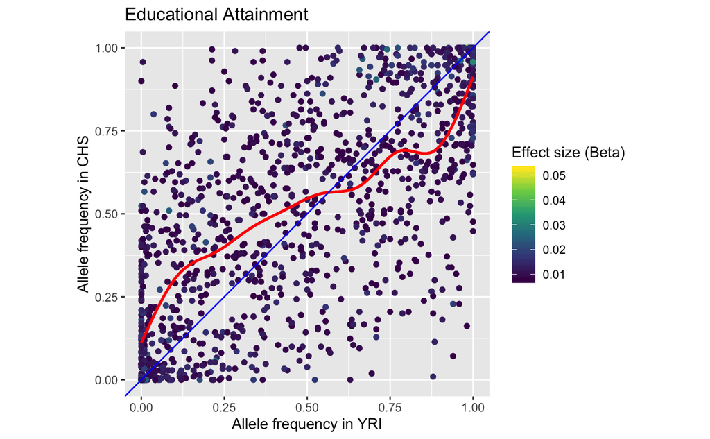

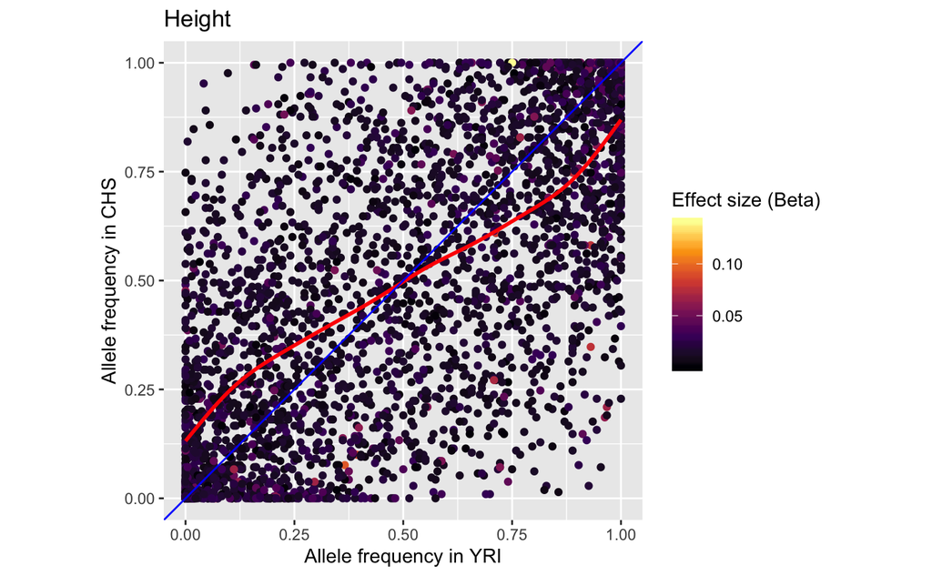

```r
counter <- 0
lapply(plot_df_lst, function(pheno){
  counter <<- counter + 1
  ggplot(pheno, aes(al_freq_YRI, al_freq_CHS, colour = effect_size)) +
    geom_point() +
    scale_color_viridis_c(option = colour_pals[counter]) +
    coord_fixed() +
    geom_smooth(se = F, colour = line_cols[counter]) +
    geom_abline(intercept = 0, slope = 1, colour = "blue") +
    xlab("Allele frequency in YRI") +
    ylab("Allele frequency in CHS") +
    labs(title = titles[counter],
         colour = legend_title[counter])
})
```

# Fst

## Create data frames

```r
# Try without population column
vcf_list_raw <- lapply(target_vcfs, function(vcf_file){
  vcf_out <- pegas::read.vcf(vcf_file)
})
```

[output not shown]

[output cut: 37 more lines]

[output not shown]

## Plot

```r
ggplot(fst_out_df, aes(Fst, fill = phenotype)) +
  geom_density(alpha = 0.7) +
  labs(fill = "Phenotype") +
  ylab("Density") +
  theme_bw()
```

[output not shown]

*20200330*

From EB: “We need a stronger positive control - perhaps can you get skin pigmentation loci?”

# Re-do with skin pigmentation positive control

## Find papers with associated SNPs

Others compiled into the single XLSX doc `data/20200622_pigmentation_snps.xlsx`: • ‘20190321_Jonnalagadda-et-al’: **Jonnalagadda et al. (2019)** A Genome-Wide Association Study of Skin and Iris Pigmentation among Individuals of South Asian Ancestry, *Genome Biology and Evolution*: https://academic.oup.com/gbe/article/11/4/1066/5416147. Took 9 SNPs associated with iris colour from Table 1, and 14 SNPs described in previous studies from Table 2. • ‘20171130_Martin-et-al’: **Martin et al. (2017)** An Unexpectedly Complex Architecture for Skin Pigmentation in Africans, *Cell*: https://www.cell.com/cell/fulltext/S0092-8674%2817%2931324-7. Took all 42 SNPs from Table S6A in Supplemental Information here: https://www.cell.com/cms/10.1016/j.cell.2017.11.015/attachment/eccead83-1a96-4444-9032-f968ee481d15/mmc2.xlsx. • ‘20150512_Liu-et-al’: **Liu et al. (2015)** Genetics of skin color variation in Europeans: genome-wide association studies with functional follow-up, *Human Genetics*: https://link.springer.com/article/10.1007%2Fs00439-015-1559-0. Took all 9 SNPs from Table 1. • ‘20121031_Candille-et-al’: **Candille et al. (2012)** Genome-wide association studies of quantitatively measured skin, hair, and eye pigmentation in four European populations, *PLoS One*: https://journals.plos.org/plosone/article?id=10.1371/journal.pone.0048294. Took all 8 SNPs from Table 2. • ‘20100614_Gerstenblith-et-al’: **Gerstenblith et al. (2010)** Genome-wide association studies of pigmentation and skin cancer: a review and meta-analysis, *Pigment Cell Melanoma Research*: https://onlinelibrary.wiley.com/doi/full/10.1111/j.1755-148X.2010.00730.x. Took all 39 SNPs from Table 4. • ‘20080516_Han-et-al’: **Han et al. (2008)** A Genome-Wide Association Study Identifies Novel Alleles Associated with Hair Color and Skin Pigmentation, *PLOS Genetics*: https://journals.plos.org/plosgenetics/article?id=10.1371/journal.pgen.1000074. Took all 38 SNPs from Table 2.

### Create list of target SNPs

```r
pig_snps <- list()
# Crawford
pig_snps[["crawford"]] <- readxl::read_excel(here("data", "20171117_Crawford-et-al_Table-1.xlsx")) %>%
  dplyr::select(rsid = "RSID", everything()) %>%
  dplyr::filter(!is.na(rsid),
                !rsid == ".")

# Adhikari
pig_snps[["adhikari_tbl_1"]] <- readxl::read_excel(here("data", "20190121_Adhikari-et-al_snps.xlsx"),
                                                   sheet = "Table 1",
                                                   skip = 1) %>%
  dplyr::select(rsid = "rsID", everything()) %>%
  dplyr::filter(!is.na(rsid))

pig_snps[["adhikari_supp_6"]] <- readxl::read_excel(here("data", "20190121_Adhikari-et-al_snps.xlsx"),
                                                   sheet = "supp_table_6") %>%
  dplyr::select(rsid = "SNP", everything()) %>%
  dplyr::filter(!is.na(rsid))

pig_snps[["adhikari_supp_12"]] <- readxl::read_excel(here("data", "20190121_Adhikari-et-al_snps.xlsx"),
                                                   sheet = "supp_table_12") %>%
  dplyr::select(rsid = "SNP", everything()) %>%
  dplyr::filter(!is.na(rsid))

# Hernandez-Pacheco
pig_snps[["hernandez-pacheco"]] <- readxl::read_excel(here("data", "20170316_Hernandez-Pacheco-et-al.xlsx"))

# Doc with SNPs from multiple studies
sheet_names <- readxl::excel_sheets(here("data", "20200622_pigmentation_snps.xlsx"))
compiled_snps <- lapply(sheet_names, function(x){
  x <- readxl::read_excel(here("data", "20200622_pigmentation_snps.xlsx"),
                     sheet = x)
})
names(compiled_snps) <- sheet_names

# Combine
pig_snps <- c(pig_snps, compiled_snps)
```

### Get summary stats

```r
# How many total SNPs
sum(unlist(lapply(pig_snps, nrow)))
```

```
[1] 414
```

### Pull out unique SNPs

```r
pig_df <- lapply(pig_snps, function(x) dplyr::select(x, rsid))
pig_df <- dplyr::bind_rows(pig_df)
pig_df <- unique(pig_df)

nrow(pig_df)
```

```
[1] 266
```

### Write table

```r
write.table(x = pig_df$rsid,
            file = here::here("data", "20200622_snps_pig.list"),
            quote = F,
            row.names = F,
            col.names = F)
```

### Extract calls for those SNPs from VCF

```bash
gatk SelectVariants \
  -R refs/hs37d5.fa.gz \
  -V vcfs/1gk_all.vcf.gz \
  --keep-ids racist_hypothesis/data/20200622_snps_pig.list \
  -O vcfs/snphits_pig.vcf.gz
```

### Copy back to data folder

```r
cp vcfs/snphits_pig.vcf.gz* racist_hypothesis/data/
```

## Get metadata

```r
meta <- read_xlsx(here::here("data", "20130606_sample_info.xlsx"), sheet = "Sample Info") %>% dplyr::select(Sample, Population, Gender)
```

[output not shown]

## Read in VCFs and obtain allele counts for target SNPs

```r
# read in VCFs and get allele counts
vcf_list <- lapply(target_vcfs, function(vcf_file){
  # read in VCFs
  vcf_out <- pegas::read.vcf(vcf_file)
  # create population column
  populations <- unlist(lapply(rownames(vcf_out), function(sample){
    meta$Population[meta$Sample == sample]
  }))
  vcf_out$population <- populations
  # reorder
  vcf_out <- vcf_out %>% dplyr::select(population, everything())
  # split by population
  vcf_out_split <- split(vcf_out, f = vcf_out$population)
  # remove population columns
  vcf_out_split <- lapply(vcf_out_split, function(x){
    x$population <- NULL
    return(x)
  })
#  # get allele counts
#  allele_counts <- lapply(vcf_out_split, function(population){
#    summary(population)
#  })
#  return(allele_counts)
})
```

[output not shown]

## Not working well. Try `vcfR`

```r
test <- vcfR::read.vcfR(target_vcfs[1])
```

[output not shown]

```
The following INFO key occurred more than once: AC
The following INFO key occurred more than once: AF
The following INFO key occurred more than once: DP
```